# Random R Codes Part-2

2014-12-30

[interactive chart not shown]

R is now a large community. Today we have 6,139 R packages. I am planning here to jot down the code snippets based on the newer packages (by following [table of available packages, sorted by date of publication](http://cran.r-project.org/web/packages/available_packages_by_date.html)). The chunk of the codes will be taken either from the Vignette or from the main package documentation pdf. I also like to include [stack overflow threads](http://stackoverflow.com/questions/tagged/r) if there are interesting questions. These interesting and easy-to-apply codes will be applied to different data sets to develop models and assumptions. Here’s **Part 2**.

Five Packages used in Part 2. [Why 5? [Here’s why.](http://petewarden.com)]

> BCDating, historydata, USAboundaries, verification, dygraphs

#### BCDating

1. [Package pdf](http://cran.r-project.org/web/packages/BCDating/BCDating.pdf).
2. Last updated: 2014-12-30

Code chunk for Business Cycle Dating and Plotting Tools.

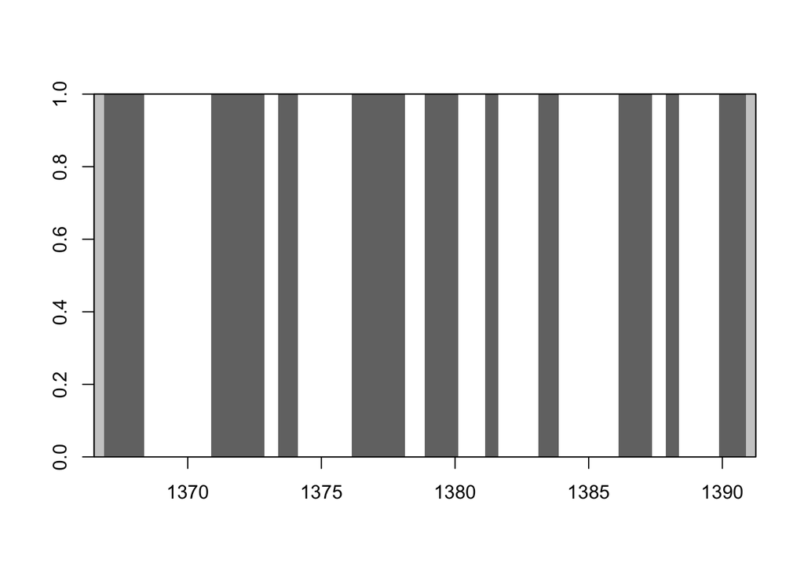

```r
library(BCDating)
data("Iran.non.Oil.GDP.Cycle")
dat <- BBQ(Iran.non.Oil.GDP.Cycle, name="Dating Business Cycles of Iran")
plot(dat)
```

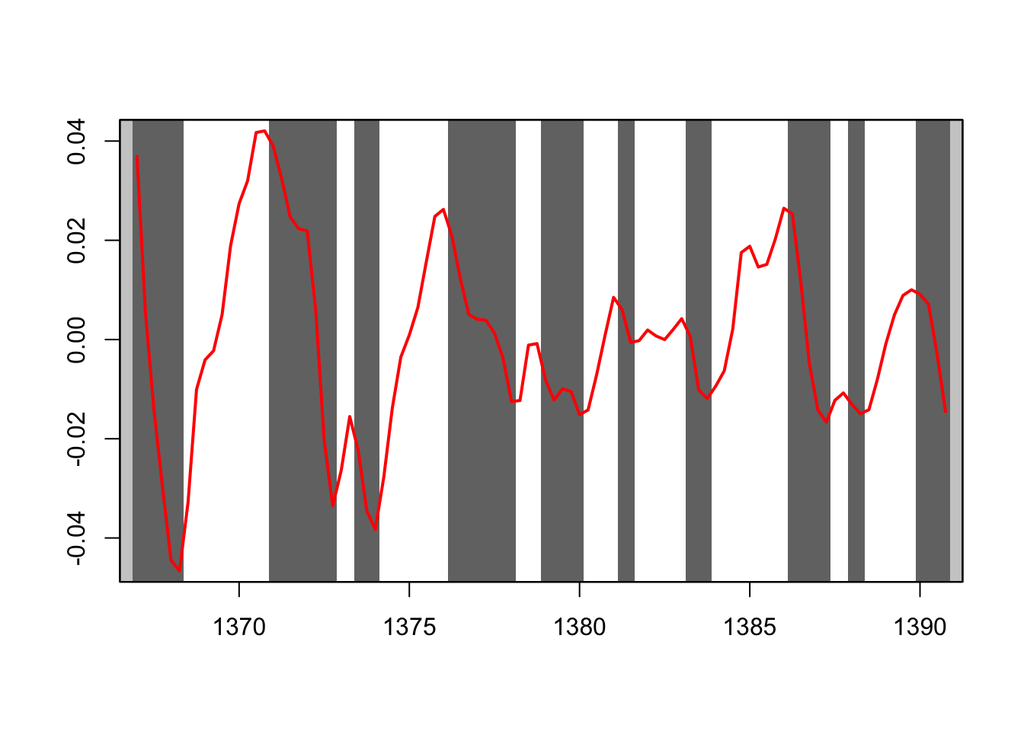

```r
plot(dat,Iran.non.Oil.GDP.Cycle)
```

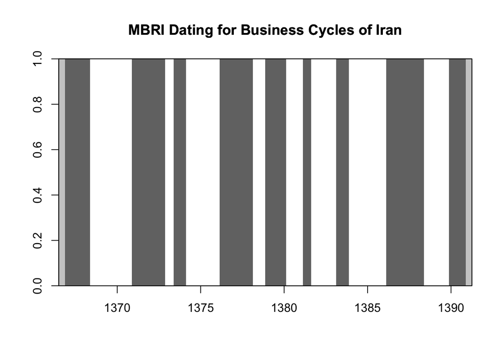

```r
data("MBRI.Iran.Dating")
plot(MBRI.Iran.Dating)
```

```r
data("Iran.non.Oil.GDP.Quarterly.Growth")
data("MBRI.Iran.Dating")
avggrowth <- avgts(Iran.non.Oil.GDP.Quarterly.Growth,MBRI.Iran.Dating)
```

Code chunk for Business Cycle Dating and Plotting Tools.

#### historydata

1. [Package pdf](http://cran.r-project.org/web/packages/historydata/historydata.pdf).
2. [Git Repository](https://github.com/ropensci/historydata).
3. Last updated: 2014-12-29

Two stackoverflow threads.

1. [To get the list of data sets in a particular R package](http://stackoverflow.com/questions/27709936/to-get-the-list-of-data-sets-in-a-particular-r-package)
2. [Capture output of data](http://stackoverflow.com/questions/15183165/capture-output-of-data)

```r
library(historydata)
data.frame(data(package = "historydata")$results)[-c(1, 2)]
```

```
##                      Item
## 1       catholic_dioceses
## 2          early_colleges
## 3     judges_appointments
## 4           judges_people
## 5        naval_promotions
## 6        paulist_missions
## 7                   sarna
## 8                  tudors
## 9  us_national_population
## 10   us_state_populations
##                                                               Title
## 1  Roman Catholic dioceses in the United States, Canada, and Mexico
## 2                               Early colleges in the United States
## 3                    Federal judges in the United States of America
## 4                    Federal judges in the United States of America
## 5                       Promotions of U.S. Navy officers, 1798-1849
## 6        Records of missions held by the Paulist Fathers, 1851-1893
## 7                             Population estimates of American Jews
## 8                                                     Tudor dynasty
## 9                        Population of the United States, 1790-2010
## 10              Populations of US states and territories, 1790-2010
```

```r
# Roman Catholic dioceses in the United States, Canada, and Mexico
dim(catholic_dioceses)
```

```
## [1] 425   6
```

```r
# Early colleges in the United States
head(early_colleges)
```

```
##                  college         original_name         city state
## 1                Harvard                  <NA>    Cambridge    MA
## 2       William and Mary                  <NA> Williamsburg    VA
## 3                   Yale                  <NA>    New Haven    CT
## 4 Pennsylvania, Univ. of                  <NA> Philadelphia    PA
## 5              Princeton College of New Jersey    Princeton    NJ
## 6               Columbia        King's College     New York    NY
##   established                          sponsorship
## 1        1636 Congregational; after 1805 Unitarian
## 2        1693                             Anglican
## 3        1701                       Congregational
## 4        1740                    Nondenominational
## 5        1746                         Presbyterian
## 6        1754                             Anglican
```

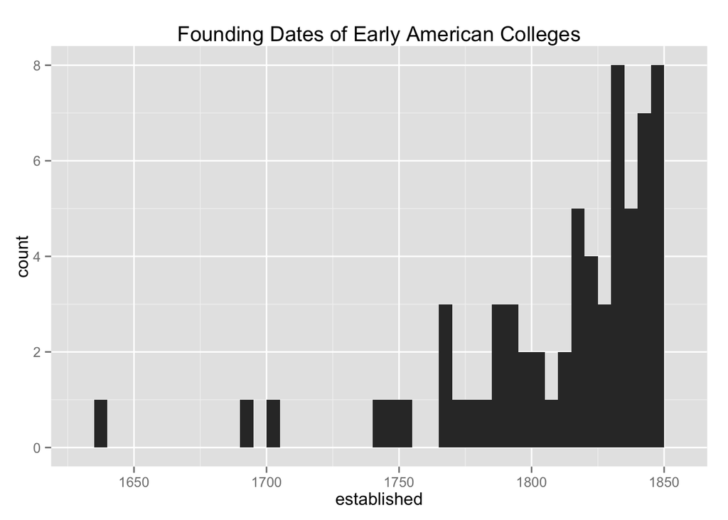

```r
if(require(ggplot2))
    {
      ggplot(early_colleges, aes(x = established)) + geom_bar(binwidth = 5) +
      ggtitle("Founding Dates of Early American Colleges")
    }
```

```r
dim(early_colleges)
```

```
## [1] 65  6
```

```r
# Population estimates of American Jews
head(sarna, 2)
```

```
##   year       estimate value
## 1 1660 population_low    50
## 2 1700 population_low   200
```

```r
dim(sarna)
```

```
## [1] 92  3
```

```r
head(us_national_population)
```

```
##   year population
## 1 1790    3929625
## 2 1800    5308483
## 3 1810    7239881
## 4 1820    9638239
## 5 1830   12860702
## 6 1840   17063353
```

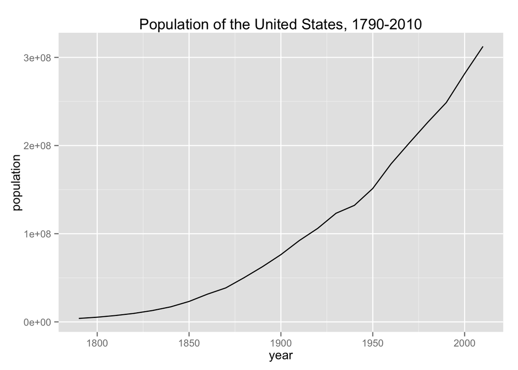

```r
if(require(ggplot2))
    {
      ggplot(us_national_population,
             aes(x = year, y = population)) +
      geom_line() +
      ggtitle("Population of the United States, 1790-2010")
    }
```

```r
head(us_state_populations, 2)
```

```
##   GISJOIN year       state population
## 1    G090 1790 Connecticut     237655
## 2    G100 1790    Delaware      59096
```

```r
dim(us_state_populations)
```

```
## [1] 983   4
```

#### USAboundaries

1. [Package pdf](http://cran.r-project.org/web/packages/USAboundaries/USAboundaries.pdf).
2. [Vignette](http://cran.r-project.org/web/packages/USAboundaries/vignettes/usboundaries.html).
3. [Git Repository](https://github.com/ropensci/USAboundaries).
4. Last updated: 2014-12-29

```r
library(USAboundaries)
data.frame(data(package = "USAboundaries")$results)[-c(1, 2)]
```

```
##               Item
## 1 hist_us_counties
## 2   hist_us_states
##                                                               Title
## 1 Boundaries of counties in the United States of America, 1629-2000
## 2   Boundaries of states in the United States of America, 1783-2000
```

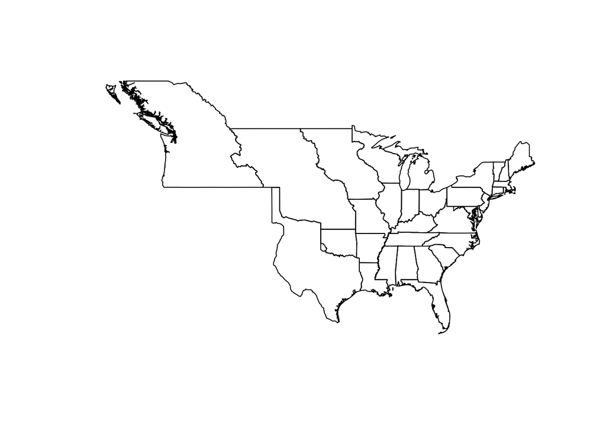

```r
library(maptools)
library(sp)
library(ggplot2)

us_1844 <- us_boundaries(as.Date("1844-07-04"))
plot(us_1844)
```

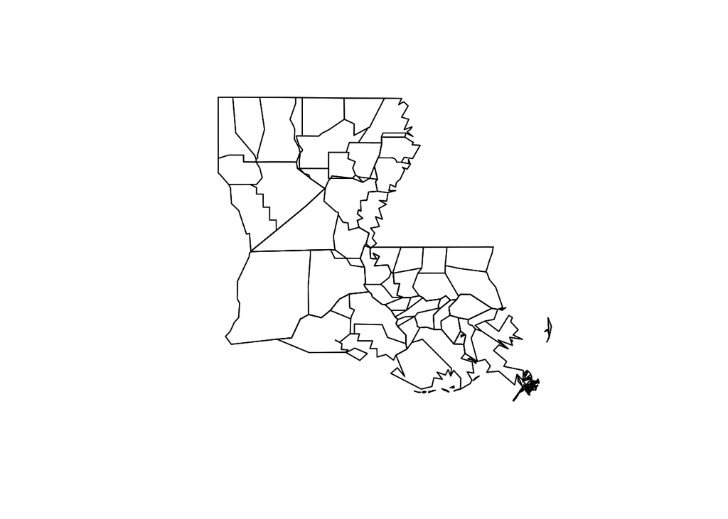

```r
va_1844 <- us_boundaries(as.Date("1844-07-04"), states = "Louisiana", type = "county")
plot(va_1844)
```

```r
# head(hist_us_counties)    # don't run ever
# head(hist_us_states)      # don't run ever
```

#### verification

1. [Package pdf](http://cran.r-project.org/web/packages/verification/verification.pdf).
2. Last updated: 2014-12-29

```r
library(verification)
data.frame(data(package = "verification")$results)[-c(1, 2)]
```

```
##              Item                                    Title
## 1        disc.dat             Discrimination plot dataset.
## 2             pop Probability of precipitation (pop) data.
## 3 precip.ensemble   An ensemble of precipitation forecasts
## 4   prob.frcs.dat          Probablisitic Forecast Dataset.
```

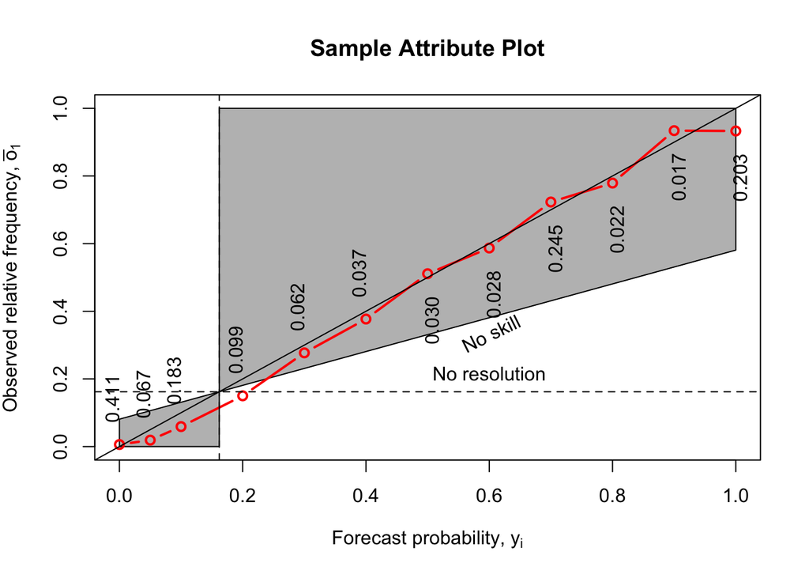

```r
## Data from Wilks, table 7.3 page 246.
## Book: Wilks, D. S. (1995) Statistical Methods in the Atmospheric Sciences Chapter 7, San Diego: Aca- demic Press.

y.i   <- c(0,0.05, seq(0.1, 1, 0.1))
obar.i <- c(0.006, 0.019, 0.059, 0.15, 0.277, 0.377, 0.511,
                 0.587, 0.723, 0.779, 0.934, 0.933)
prob.y<- c(0.4112, 0.0671, 0.1833, 0.0986, 0.0616, 0.0366,
                0.0303,  0.0275, 0.245, 0.022, 0.017, 0.203)
obar<- 0.162

attribute(y.i, obar.i, prob.y, obar, main = "Sample Attribute Plot")
```

```r
obs<- round(runif(100))
pred<- runif(100)
A<- verify(obs, pred, frcst.type = "prob", obs.type = "binary")
```

```
## If baseline is not included, baseline values  will be calculated from the  sample obs.
```

```r
attribute(A, main = "Alternative plot", xlab = "Alternate x label")
```

```r
## to add a line from another model
obs<- round(runif(100))
pred<- runif(100)
B<- verify(obs, pred, frcst.type = "prob", obs.type = "binary")
```

```
## If baseline is not included, baseline values  will be calculated from the  sample obs.
```

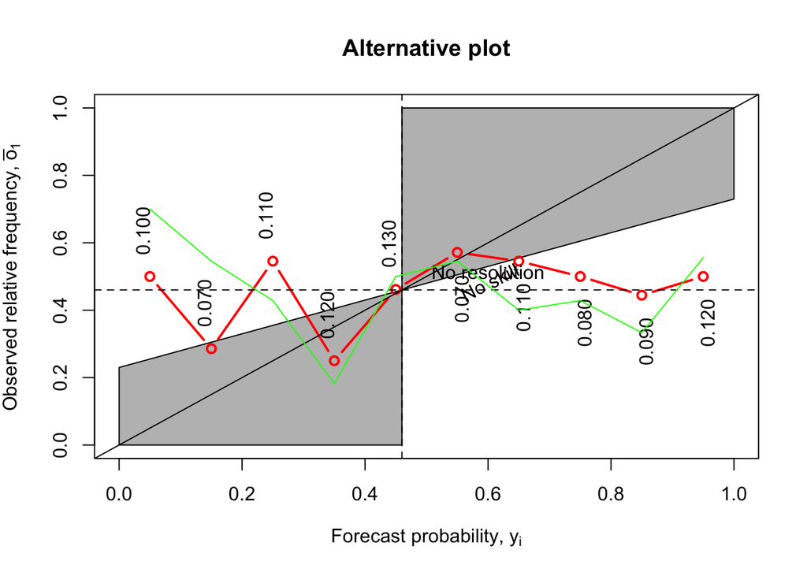

```r
lines.attrib(B, col = "green")
```

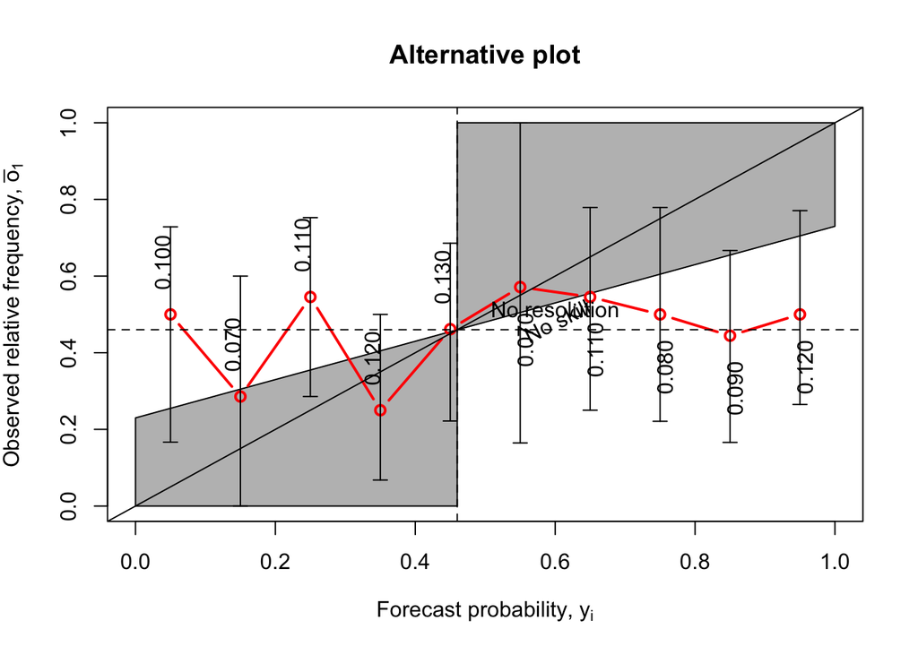

```r
## Same with confidence intervals
attribute(A, main = "Alternative plot", xlab = "Alternate x label", CI =TRUE)
```

```r
#### add lines to plot
data(pop)
d <- pop.convert()

mod24 <- verify(d$obs_rain, d$p24_rain, bins = FALSE)
```

```
## If baseline is not included, baseline values  will be calculated from the  sample obs.
```

```r
mod48 <- verify(d$obs_rain, d$p48_rain, bins = FALSE)
```

```
## If baseline is not included, baseline values  will be calculated from the  sample obs.
```

```r
plot(mod24, freq = FALSE)
```

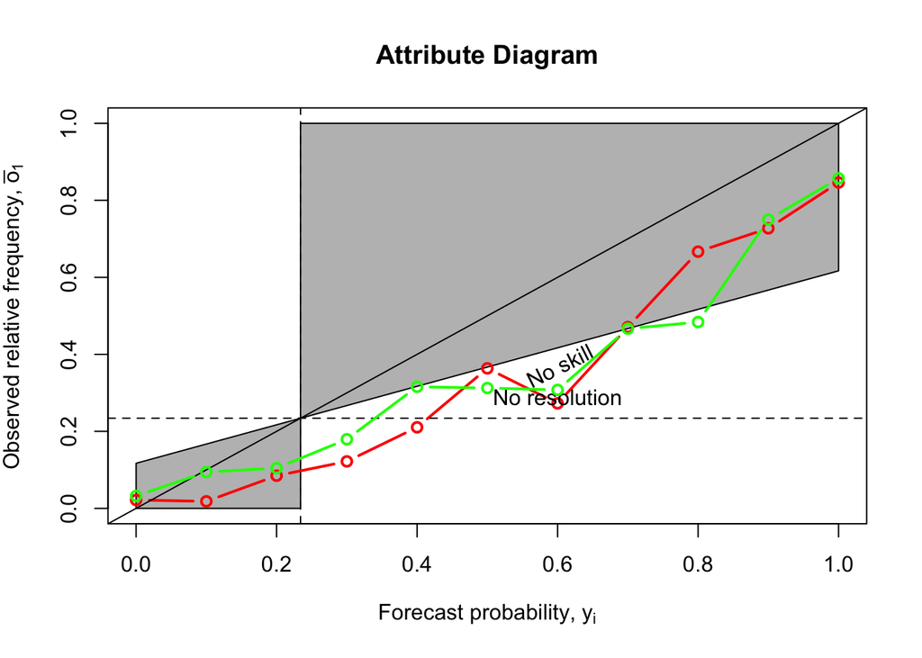

```r
lines.attrib(mod48, col = "green", lwd = 2, type = "b")
```

#### dygraphs

[dygraphs](http://dygraphs.com) is a fast, flexible open source JavaScript charting library.

1. [Package pdf](http://cran.r-project.org/web/packages/dygraphs/dygraphs.pdf).
2. [Git Repository](http://rstudio.github.io/dygraphs/).
3. [Stack Overflow Questions](http://stackoverflow.com/questions/tagged/dygraphs)
4. Last updated: 2014-12-29

```r
library(dygraphs)
dygraph(presidents, main = "Presidential Approval") %>%
      dyAxis("y", valueRange = c(0, 100)) %>%
      dyAnnotation("1950-7-1", text = "A", tooltip = "Korea") %>%
      dyAnnotation("1965-1-1", text = "B", tooltip = "Vietnam")
```

[interactive chart not shown]

- Compiled by [Subasish Das](http://subasish.tumblr.com)